Portfolio research report

# Breast Cancer Survival in the Rotterdam Tumor Bank

Prognostic factors, treatment selection, and survival outcomes

Author

**Rabbi Tweneboah**

Focus

Epidemiological methods · Survival analysis · Public health

Tools

R · Quarto · HTML+CSS

Current scope

Stage 1–2 results

Reproducible research portfolio

Executive summary

# What the analysis shows so far

Stage 1–2

This study uses the Rotterdam Tumor Bank cohort to examine overall survival among women with primary breast cancer, with particular attention to treatment selection and the observed survival experience of women who did and did not receive chemotherapy.

2,982

women in the analytic cohort

9.27

years median potential follow-up

11.04

years median overall survival

0.482

log-rank p-value for crude chemotherapy comparison

## Key findings

- Five-year overall survival was approximately **74.4%**, declining to **55.2%** at 10 years and **39.1%** at 15 years.
- Women receiving chemotherapy were substantially different from untreated women at baseline, particularly with respect to age, menopausal status, lymph-node involvement, and estrogen-receptor levels.
- Crude Kaplan–Meier survival was broadly similar across chemotherapy groups; the log-rank test did not identify a statistically significant difference (**p = 0.482**).
- The large baseline imbalances mean that crude treatment-group comparisons should not be interpreted as causal treatment effects.

Interpretation

Current results indicates treatment selection problem, not treatment effectiveness.

Chemotherapy was not randomly assigned. Stage 3 should therefore focus on covariate-adjusted survival modelling and the extent to which the crude chemotherapy–survival association changes after adjustment.

## Reader-oriented report structure

Section

Purpose

1. Study context

Why treatment selection matters in observational breast-cancer survival data

2. Cohort and treatment selection

Who is represented and how chemotherapy groups differ at baseline

3. Non-parametric survival analysis

Overall and chemotherapy-stratified Kaplan–Meier estimates

4. Multivariable modelling

Cox regression and the adjusted chemotherapy–survival association

5. Robustness and discussion

Model assumptions, sensitivity analyses, interpretation, and limitations

Stage 1

Stage 2

Stage 3

Stage 4

Cohort characterization and treatment selection

# Baseline risk differs substantially by chemotherapy status

Before comparing survival outcomes, the analysis evaluates whether women who received chemotherapy were comparable with those who did not. Standardized mean differences (SMDs) show pronounced baseline imbalance in several clinically relevant characteristics.

## Selected baseline characteristics

Characteristic

No chemotherapy

Chemotherapy

Sample size

2,402

580

Age, mean (SD)

57.6 (12.8)

44.7 (7.3)

Postmenopausal

1,581 (65.8%)

89 (15.3%)

Positive lymph nodes, median [IQR]

0.0 [0.0, 3.0]

2.0 [1.0, 5.0]

Estrogen receptor, median [IQR]

73.0 [12.0, 234.0]

40.0 [10.0, 98.2]

Why it matters

The chemotherapy group is younger but has greater lymph-node involvement and somewhat larger tumours. These differences are consistent with non-random treatment allocation and motivate covariate adjustment in later modelling.

## Magnitude of baseline imbalance

Age

1.235

Menopausal status

1.198

Positive lymph nodes

0.415

Estrogen receptor

0.362

Tumour size

0.160

Progesterone receptor

0.072

Year of incidence

0.012

Tumour grade

0.002

Absolute SMDs summarize covariate imbalance; values above 0.10 indicate potentially meaningful imbalance. Bar lengths use a common scale from 0 to 1.25.

Treatment allocation

19.5%

of the cohort received chemotherapy (580 of 2,982 women)

Confounding risk

Treatment allocation is strongly associated with several prognostic characteristics. This creates substantial potential for confounding by treatment selection, making crude chemotherapy–survival comparisons insufficient for treatment-effect interpretation.

Stage 1

Stage 2

Stage 3

Stage 4

Non-parametric survival analysis

# Observed survival before covariate adjustment

Kaplan–Meier estimation describes the cohort’s observed survival experience without imposing a parametric survival distribution. Landmark estimates provide an accessible summary of survival over follow-up, while treatment-stratified curves describe crude differences between chemotherapy groups.

98.0%

1-year survival

74.4%

5-year survival

55.2%

10-year survival

39.1%

15-year survival

## Overall survival trajectory

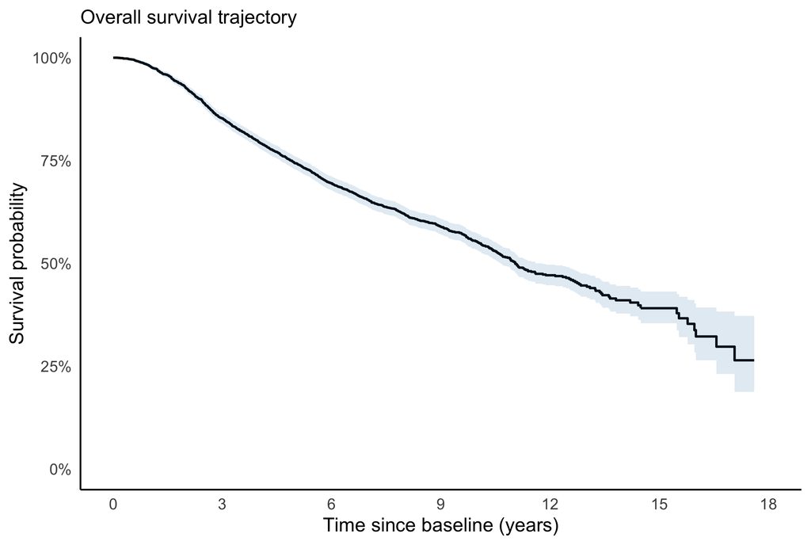

## Survival by chemotherapy status

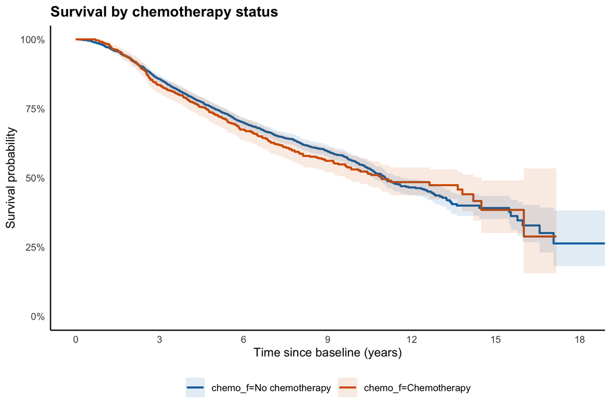

What the curves show

The chemotherapy-stratified survival curves overlap substantially across follow-up, with no clear or sustained separation. The curves converge and cross later in follow-up, while uncertainty increases as fewer women remain under observation.

## Crude survival by treatment group

Landmark

Chemotherapy

No chemotherapy

1 year

98.8%

97.8%

5 years

72.8%

74.7%

10 years

53.0%

55.7%

15 years

38.4%

39.1%

Median

10.92 y

11.04 y

Crude chemotherapy comparison

p = 0.482

Log-rank test comparing the unadjusted survival distributions

Interpretation

The log-rank test does not provide evidence of a difference in the unadjusted survival distributions. This does not establish equivalence between treatment groups and should not be interpreted as evidence that chemotherapy has no effect.